# EDA_EXAM_Shatanu_sangale

#### Now filling Null values of occupation type based on the proportion

```python
# Raw proportions
occupation_proportions = {
    'Labourers': 0.2424,
    'Sales staff': 0.1410,
    'Core staff': 0.1211,
    'Managers': 0.0939,
    'Drivers': 0.0817,
    'High skill tech staff': 0.0500,
    'Accountants': 0.0431,
    'Medicine staff': 0.0375,
    'Security staff': 0.0295,
    'Cooking staff': 0.0261,
    'Cleaning staff': 0.0204,
    'Private service staff': 0.0117,
    'Low-skill Laborers': 0.0092,
    'Waiters/barmen staff': 0.0059,
    'Secretaries': 0.0057,
    'Realty agents': 0.0033,
    'HR staff': 0.0025,
    'IT staff': 0.0023,
}
```

```python
# Normalize proportions to ensure they sum to 1
total_proportion = sum(occupation_proportions.values())
normalized_proportions = {k: v / total_proportion for k, v in occupation_proportions.items()}
```

```python
# Extract categories and normalized proportions
categories = list(normalized_proportions.keys())
proportions = list(normalized_proportions.values())
```

```python
# Assign null values proportionally
null_indices = df_appl['Occupation Type'].isnull()
df_appl.loc[null_indices, 'Occupation Type'] = np.random.choice(categories, size=null_indices.sum(), p=proportions)
```

```python
df_appl.isnull().sum()
```

```
LoanID                               0
Target                               0
Loan Type                            0
Gender                               0
Own Car                              0
Own House                            0
No Of Children                       0
Client Income                        0
Loan Amount                          0
Loan Annuity                        12
Loan Goods Price                   278
Accompanied By                    1292
Profession                           0
Education                            0
Marital Status                       0
House Type                           0
Client Region Population             0
Age                                  0
Current Employment Days              0
Registration Change Days             0
ID Change Days                       0
Mobile Phone                         0
Work Phone                           0
Home Phone                           0
Mobile Verification                  0
Home Phone Verification              0
Email                                0
Occupation Type                      0
Family Members                       2
Region Rating                        0
City Rating                          0
Application day                      0
Application Hour                     0
Perm add not match contact add       0
Perm add not match work add          0
Contact add not match work add       0
Organization Type                    0
Phone Changed Days                   1
dtype: int64
```

```python
df_appl['Loan Annuity'].mean()
```

```
np.float64(27108.573909183444)
```

```python
# Fill null values in 'Loan Annuity' with the mean of the column
df_appl['Loan Annuity'].fillna(df_appl['Loan Annuity'].mean(), inplace=True)
```

```python
df_appl['Loan Goods Price'].mean()
```

```
np.float64(538396.2074288895)
```

```python
# Fill null values in 'Loan Goods Price' with the mean of the column
df_appl['Loan Goods Price'].fillna(df_appl['Loan Goods Price'].mean(), inplace=True)
```

```python
# Fill null values in 'Accompanied by' with 'Unaccompanied'
df_appl['Accompanied By'].fillna('Unaccompanied', inplace=True)
```

```python
# Fill null values in 'Family Members' with '2'
df_appl['Family Members'].fillna(2, inplace=True)
```

```python
# Fill null values in 'Phone Changed Days' with '0.00'
df_appl['Phone Changed Days'].fillna(0.00, inplace=True)
```

```python
df_appl.isnull().sum()   #All null values are managed
```

```
LoanID                            0
Target                            0
Loan Type                         0
Gender                            0
Own Car                           0
Own House                         0
No Of Children                    0
Client Income                     0
Loan Amount                       0
Loan Annuity                      0
Loan Goods Price                  0
Accompanied By                    0
Profession                        0
Education                         0
Marital Status                    0
House Type                        0
Client Region Population          0
Age                               0
Current Employment Days           0
Registration Change Days          0
ID Change Days                    0
Mobile Phone                      0
Work Phone                        0
Home Phone                        0
Mobile Verification               0
Home Phone Verification           0
Email                             0
Occupation Type                   0
Family Members                    0
Region Rating                     0
City Rating                       0
Application day                   0
Application Hour                  0
Perm add not match contact add    0
Perm add not match work add       0
Contact add not match work add    0
Organization Type                 0
Phone Changed Days                0
dtype: int64
```

```python
df_appl.count()  #The data is consistent now
```

```
LoanID                            307511
Target                            307511
Loan Type                         307511
Gender                            307511
Own Car                           307511
Own House                         307511
No Of Children                    307511
Client Income                     307511
Loan Amount                       307511
Loan Annuity                      307511
Loan Goods Price                  307511
Accompanied By                    307511
Profession                        307511
Education                         307511
Marital Status                    307511
House Type                        307511
Client Region Population          307511
Age                               307511
Current Employment Days           307511
Registration Change Days          307511
ID Change Days                    307511
Mobile Phone                      307511
Work Phone                        307511
Home Phone                        307511
Mobile Verification               307511
Home Phone Verification           307511
Email                             307511
Occupation Type                   307511
Family Members                    307511
Region Rating                     307511
City Rating                       307511
Application day                   307511
Application Hour                  307511
Perm add not match contact add    307511
Perm add not match work add       307511
Contact add not match work add    307511
Organization Type                 307511
Phone Changed Days                307511
dtype: int64
```

```python
df_prev.head()
```

|  | SK_ID_PREV | SK_ID_CURR | NAME_CONTRACT_TYPE | AMT_ANNUITY | AMT_APPLICATION | AMT_CREDIT | AMT_DOWN_PAYMENT | AMT_GOODS_PRICE | WEEKDAY_APPR_PROCESS_START | HOUR_APPR_PROCESS_START | ... | NAME_SELLER_INDUSTRY | CNT_PAYMENT | NAME_YIELD_GROUP | PRODUCT_COMBINATION | DAYS_FIRST_DRAWING | DAYS_FIRST_DUE | DAYS_LAST_DUE_1ST_VERSION | DAYS_LAST_DUE | DAYS_TERMINATION | NFLAG_INSURED_ON_APPROVAL |
| --- | --- | --- | --- | --- | --- | --- | --- | --- | --- | --- | --- | --- | --- | --- | --- | --- | --- | --- | --- | --- | --- |
| 0 | 2030495 | 271877 | Consumer loans | 1730.43 | 17145.00 | 17145.00 | 0.00 | 17145.00 | SATURDAY | 15 | ... | Connectivity | 12.00 | middle | POS mobile with interest | 365243.00 | -42.00 | 300.00 | -42.00 | -37.00 | 0.00 |
| 1 | 2802425 | 108129 | Cash loans | 25188.62 | 607500.00 | 679671.00 | NaN | 607500.00 | THURSDAY | 11 | ... | XNA | 36.00 | low_action | Cash X-Sell: low | 365243.00 | -134.00 | 916.00 | 365243.00 | 365243.00 | 1.00 |
| 2 | 2523466 | 122040 | Cash loans | 15060.74 | 112500.00 | 136444.50 | NaN | 112500.00 | TUESDAY | 11 | ... | XNA | 12.00 | high | Cash X-Sell: high | 365243.00 | -271.00 | 59.00 | 365243.00 | 365243.00 | 1.00 |
| 3 | 2819243 | 176158 | Cash loans | 47041.33 | 450000.00 | 470790.00 | NaN | 450000.00 | MONDAY | 7 | ... | XNA | 12.00 | middle | Cash X-Sell: middle | 365243.00 | -482.00 | -152.00 | -182.00 | -177.00 | 1.00 |
| 4 | 1784265 | 202054 | Cash loans | 31924.40 | 337500.00 | 404055.00 | NaN | 337500.00 | THURSDAY | 9 | ... | XNA | 24.00 | high | Cash Street: high | NaN | NaN | NaN | NaN | NaN | NaN |

5 rows × 37 columns

```python
df_appl['Gender'].value_counts()
```

```
Gender
F      202448
M      105059
XNA         4
Name: count, dtype: int64
```

```python
# Replace 'XNA' with 'F' in the 'Gender' column
df_appl['Gender'].replace('XNA', 'F', inplace=True)
```

## Now cleaning the 2nd dataset

```python
df_prev.head()
```

|  | SK_ID_PREV | SK_ID_CURR | NAME_CONTRACT_TYPE | AMT_ANNUITY | AMT_APPLICATION | AMT_CREDIT | AMT_DOWN_PAYMENT | AMT_GOODS_PRICE | WEEKDAY_APPR_PROCESS_START | HOUR_APPR_PROCESS_START | ... | NAME_SELLER_INDUSTRY | CNT_PAYMENT | NAME_YIELD_GROUP | PRODUCT_COMBINATION | DAYS_FIRST_DRAWING | DAYS_FIRST_DUE | DAYS_LAST_DUE_1ST_VERSION | DAYS_LAST_DUE | DAYS_TERMINATION | NFLAG_INSURED_ON_APPROVAL |
| --- | --- | --- | --- | --- | --- | --- | --- | --- | --- | --- | --- | --- | --- | --- | --- | --- | --- | --- | --- | --- | --- |
| 0 | 2030495 | 271877 | Consumer loans | 1730.43 | 17145.00 | 17145.00 | 0.00 | 17145.00 | SATURDAY | 15 | ... | Connectivity | 12.00 | middle | POS mobile with interest | 365243.00 | -42.00 | 300.00 | -42.00 | -37.00 | 0.00 |
| 1 | 2802425 | 108129 | Cash loans | 25188.62 | 607500.00 | 679671.00 | NaN | 607500.00 | THURSDAY | 11 | ... | XNA | 36.00 | low_action | Cash X-Sell: low | 365243.00 | -134.00 | 916.00 | 365243.00 | 365243.00 | 1.00 |
| 2 | 2523466 | 122040 | Cash loans | 15060.74 | 112500.00 | 136444.50 | NaN | 112500.00 | TUESDAY | 11 | ... | XNA | 12.00 | high | Cash X-Sell: high | 365243.00 | -271.00 | 59.00 | 365243.00 | 365243.00 | 1.00 |
| 3 | 2819243 | 176158 | Cash loans | 47041.33 | 450000.00 | 470790.00 | NaN | 450000.00 | MONDAY | 7 | ... | XNA | 12.00 | middle | Cash X-Sell: middle | 365243.00 | -482.00 | -152.00 | -182.00 | -177.00 | 1.00 |
| 4 | 1784265 | 202054 | Cash loans | 31924.40 | 337500.00 | 404055.00 | NaN | 337500.00 | THURSDAY | 9 | ... | XNA | 24.00 | high | Cash Street: high | NaN | NaN | NaN | NaN | NaN | NaN |

5 rows × 37 columns

```python
df_prev.dtypes
```

```
SK_ID_PREV                       int64
SK_ID_CURR                       int64
NAME_CONTRACT_TYPE              object
AMT_ANNUITY                    float64
AMT_APPLICATION                float64
AMT_CREDIT                     float64
AMT_DOWN_PAYMENT               float64
AMT_GOODS_PRICE                float64
WEEKDAY_APPR_PROCESS_START      object
HOUR_APPR_PROCESS_START          int64
FLAG_LAST_APPL_PER_CONTRACT     object
NFLAG_LAST_APPL_IN_DAY           int64
RATE_DOWN_PAYMENT              float64
RATE_INTEREST_PRIMARY          float64
RATE_INTEREST_PRIVILEGED       float64
NAME_CASH_LOAN_PURPOSE          object
NAME_CONTRACT_STATUS            object
DAYS_DECISION                    int64
NAME_PAYMENT_TYPE               object
CODE_REJECT_REASON              object
NAME_TYPE_SUITE                 object
NAME_CLIENT_TYPE                object
NAME_GOODS_CATEGORY             object
NAME_PORTFOLIO                  object
NAME_PRODUCT_TYPE               object
CHANNEL_TYPE                    object
SELLERPLACE_AREA                 int64
NAME_SELLER_INDUSTRY            object
CNT_PAYMENT                    float64
NAME_YIELD_GROUP                object
PRODUCT_COMBINATION             object
DAYS_FIRST_DRAWING             float64
DAYS_FIRST_DUE                 float64
DAYS_LAST_DUE_1ST_VERSION      float64
DAYS_LAST_DUE                  float64
DAYS_TERMINATION               float64
NFLAG_INSURED_ON_APPROVAL      float64
dtype: object
```

```python
df_prev.isnull().sum()
```

```
SK_ID_PREV                           0
SK_ID_CURR                           0
NAME_CONTRACT_TYPE                   0
AMT_ANNUITY                     372235
AMT_APPLICATION                      0
AMT_CREDIT                           1
AMT_DOWN_PAYMENT                895844
AMT_GOODS_PRICE                 385515
WEEKDAY_APPR_PROCESS_START           0
HOUR_APPR_PROCESS_START              0
FLAG_LAST_APPL_PER_CONTRACT          0
NFLAG_LAST_APPL_IN_DAY               0
RATE_DOWN_PAYMENT               895844
RATE_INTEREST_PRIMARY          1664263
RATE_INTEREST_PRIVILEGED       1664263
NAME_CASH_LOAN_PURPOSE               0
NAME_CONTRACT_STATUS                 0
DAYS_DECISION                        0
NAME_PAYMENT_TYPE                    0
CODE_REJECT_REASON                   0
NAME_TYPE_SUITE                 820405
NAME_CLIENT_TYPE                     0
NAME_GOODS_CATEGORY                  0
NAME_PORTFOLIO                       0
NAME_PRODUCT_TYPE                    0
CHANNEL_TYPE                         0
SELLERPLACE_AREA                     0
NAME_SELLER_INDUSTRY                 0
CNT_PAYMENT                     372230
NAME_YIELD_GROUP                     0
PRODUCT_COMBINATION                346
DAYS_FIRST_DRAWING              673065
DAYS_FIRST_DUE                  673065
DAYS_LAST_DUE_1ST_VERSION       673065
DAYS_LAST_DUE                   673065
DAYS_TERMINATION                673065
NFLAG_INSURED_ON_APPROVAL       673065
dtype: int64
```

```python
df_prev.shape
```

```
(1670214, 37)
```

```python
df_prev.drop(['WEEKDAY_APPR_PROCESS_START',
'HOUR_APPR_PROCESS_START',
'RATE_INTEREST_PRIMARY',
'RATE_INTEREST_PRIVILEGED',
'AMT_DOWN_PAYMENT',
'RATE_DOWN_PAYMENT',
'NAME_TYPE_SUITE',
'DAYS_FIRST_DRAWING',
'DAYS_FIRST_DUE',
'DAYS_LAST_DUE_1ST_VERSION',
'DAYS_LAST_DUE',
'DAYS_TERMINATION',
'NFLAG_INSURED_ON_APPROVAL'],axis=1,inplace=True)
```

```python
df_prev.columns
```

```
Index(['SK_ID_PREV', 'SK_ID_CURR', 'NAME_CONTRACT_TYPE', 'AMT_ANNUITY',
       'AMT_APPLICATION', 'AMT_CREDIT', 'AMT_GOODS_PRICE',
       'FLAG_LAST_APPL_PER_CONTRACT', 'NFLAG_LAST_APPL_IN_DAY',
       'NAME_CASH_LOAN_PURPOSE', 'NAME_CONTRACT_STATUS', 'DAYS_DECISION',
       'NAME_PAYMENT_TYPE', 'CODE_REJECT_REASON', 'NAME_CLIENT_TYPE',
       'NAME_GOODS_CATEGORY', 'NAME_PORTFOLIO', 'NAME_PRODUCT_TYPE',
       'CHANNEL_TYPE', 'SELLERPLACE_AREA', 'NAME_SELLER_INDUSTRY',
       'CNT_PAYMENT', 'NAME_YIELD_GROUP', 'PRODUCT_COMBINATION'],
      dtype='object')
```

```python
df_prev.rename(columns={'SK_ID_PREV':'Previous LoanID', 'SK_ID_CURR':'LoanID', 'NAME_CONTRACT_TYPE':'Loan Type', 'AMT_ANNUITY':'Loan Annuity',
       'AMT_APPLICATION':'Application Amount', 'AMT_CREDIT':'Loan Amount', 'AMT_GOODS_PRICE':'Loan Goods Price',
       'FLAG_LAST_APPL_PER_CONTRACT':'More Applications', 'NFLAG_LAST_APPL_IN_DAY':'More Applications Per Day',
       'NAME_CASH_LOAN_PURPOSE':'Loan Purpose', 'NAME_CONTRACT_STATUS':'Loan Approved', 'DAYS_DECISION':'DAYS_DECISION',
       'NAME_PAYMENT_TYPE':'Payment Method', 'CODE_REJECT_REASON':'Reject Reason', 'NAME_CLIENT_TYPE':'Client Type',
       'NAME_GOODS_CATEGORY':'Goods Applied For', 'NAME_PORTFOLIO':'NAME_PORTFOLIO', 'NAME_PRODUCT_TYPE':'NAME_PRODUCT_TYPE',
       'CHANNEL_TYPE':'CHANNEL_TYPE', 'SELLERPLACE_AREA':'SELLERPLACE_AREA', 'NAME_SELLER_INDUSTRY':'Industry Of Seller',
       'CNT_PAYMENT':'Term Of Previous Credit', 'NAME_YIELD_GROUP':'Grouped Interest Rate', 'PRODUCT_COMBINATION':'PRODUCT_COMBINATION'},inplace=True)
```

```python
df_prev.drop(['DAYS_DECISION',
'NAME_PORTFOLIO',
'NAME_PRODUCT_TYPE',
'CHANNEL_TYPE',
'SELLERPLACE_AREA',
'PRODUCT_COMBINATION'],axis=1,inplace=True)
```

```python
df_prev.isnull().sum()
```

```
Previous LoanID                   0
LoanID                            0
Loan Type                         0
Loan Annuity                 372235
Application Amount                0
Loan Amount                       1
Loan Goods Price             385515
More Applications                 0
More Applications Per Day         0
Loan Purpose                      0
Loan Approved                     0
Payment Method                    0
Reject Reason                     0
Client Type                       0
Goods Applied For                 0
Industry Of Seller                0
Term Of Previous Credit      372230
Grouped Interest Rate             0
dtype: int64
```

```python
df_prev['Loan Annuity'].median()
```

```
np.float64(11250.0)
```

```python
#Replacing null values in 'Loan Annuity' column by its median
df_prev['Loan Annuity'].fillna(df_prev['Loan Annuity'].median(),inplace=True)
```

```python
df_prev.isnull().sum()
```

```
Previous LoanID                   0
LoanID                            0
Loan Type                         0
Loan Annuity                      0
Application Amount                0
Loan Amount                       1
Loan Goods Price             385515
More Applications                 0
More Applications Per Day         0
Loan Purpose                      0
Loan Approved                     0
Payment Method                    0
Reject Reason                     0
Client Type                       0
Goods Applied For                 0
Industry Of Seller                0
Term Of Previous Credit      372230
Grouped Interest Rate             0
dtype: int64
```

```python
#Replacing null values in 'Loan Amount' column by its median
df_prev['Loan Amount'].fillna(df_prev['Loan Amount'].median(),inplace=True)
```

```python
#Replacing null values in 'Loan Goods Price' column by its median
df_prev['Loan Goods Price'].fillna(df_prev['Loan Goods Price'].median(),inplace=True)
```

```python
df_prev['Term Of Previous Credit'].median()
```

```
np.float64(12.0)
```

```python
#Replacing null values in 'Term Of Previous Credit' column by its median
df_prev['Term Of Previous Credit'].fillna(df_prev['Term Of Previous Credit'].median(),inplace=True)
```

### Changing data types into category of following columns

```python
df_appl['Loan Type'] = df_appl['Loan Type'].astype('category')
df_appl['Gender'] = df_appl['Gender'].astype('category')
df_appl['Accompanied By'] = df_appl['Accompanied By'].astype('category')
df_appl['Client Income'] = df_appl['Client Income'].astype('category')
df_appl['Education'] = df_appl['Education'].astype('category')
df_appl['Marital Status'] = df_appl['Marital Status'].astype('category')
df_appl['House Type'] = df_appl['House Type'].astype('category')
df_appl['Organization Type'] = df_appl['Organization Type'].astype('category')
```

```python
df_appl.columns
```

```
Index(['LoanID', 'Target', 'Loan Type', 'Gender', 'Own Car', 'Own House',
       'No Of Children', 'Client Income', 'Loan Amount', 'Loan Annuity',
       'Loan Goods Price', 'Accompanied By', 'Profession', 'Education',
       'Marital Status', 'House Type', 'Client Region Population', 'Age',
       'Current Employment Days', 'Registration Change Days', 'ID Change Days',
       'Mobile Phone', 'Work Phone', 'Home Phone', 'Mobile Verification',
       'Home Phone Verification', 'Email', 'Occupation Type', 'Family Members',
       'Region Rating', 'City Rating', 'Application day', 'Application Hour',
       'Perm add not match contact add', 'Perm add not match work add',
       'Contact add not match work add', 'Organization Type',
       'Phone Changed Days'],
      dtype='object')
```

## Finding Outliers

### Univariate Analysis

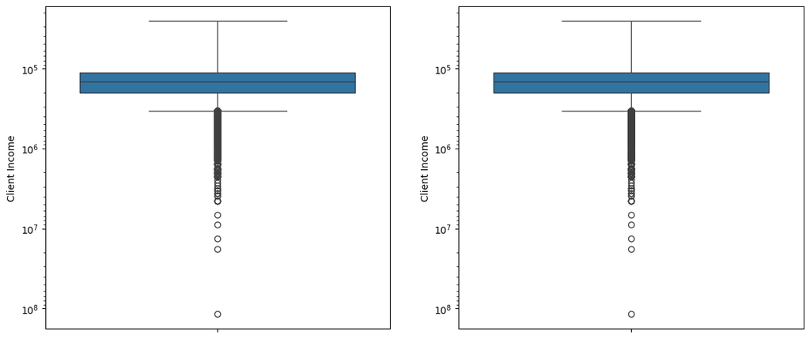

```python
plt.figure(figsize=[14,6])

plt.subplot(1,2,1)
sns.boxplot(y='Client Income',data=df_appl)
plt.yscale('log')


plt.subplot(1,2,2)
sns.boxplot(y='Client Income',data=df_appl)
plt.yscale('log')


plt.show()
```

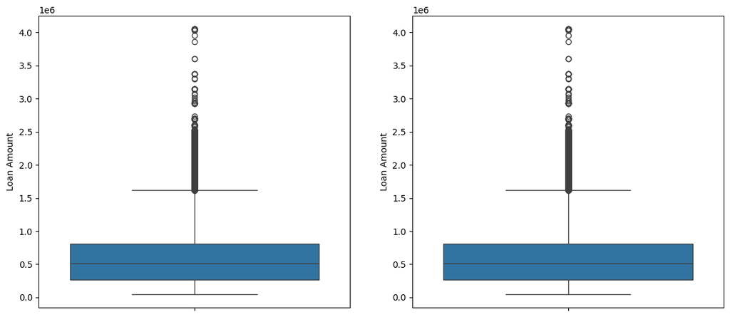

```python
plt.figure(figsize=[14,6])

plt.subplot(1,2,1)
sns.boxplot(y='Loan Amount',data=df_appl)

plt.subplot(1,2,2)
sns.boxplot(y='Loan Amount',data=df_appl)


plt.show()
```

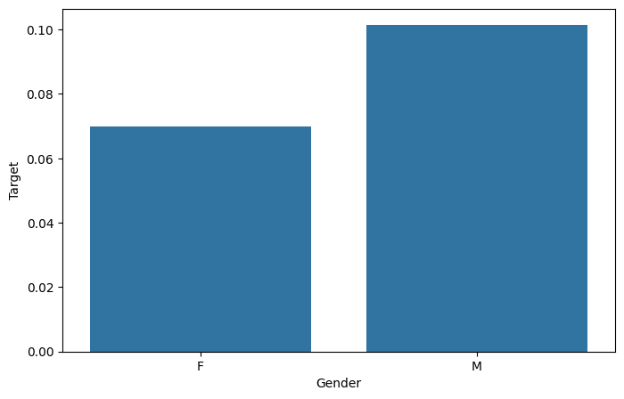

```python
plt.figure(figsize=(8,5))
sns.barplot(y=df_appl['Target'],x=df_appl['Gender'],ci=None)
```

```python
df_appl['Organization Type'].unique()
```

```
['Business Entity Type 3', 'School', 'Government', 'Religion', 'Other', ..., 'Trade: type 4', 'Telecom', 'Industry: type 8', 'Realtor', 'Industry: type 6']
Length: 58
Categories (58, object): ['Advertising', 'Agriculture', 'Bank', 'Business Entity Type 1', ..., 'Transport: type 3', 'Transport: type 4', 'University', 'XNA']
```

### Dropping missing values of 'XNA' in 'Organization Type'

```python
df_appl = df_appl.drop(df_appl.loc[df_appl['Organization Type'] =='XNA'].index)
```

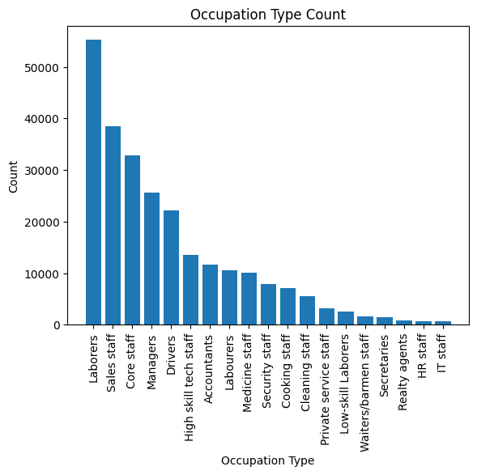

```python
occu_count = df_appl['Occupation Type'].value_counts()
plt.bar(occu_count.index, occu_count.values)
plt.xticks(rotation=90)
plt.ylabel("Count")
plt.xlabel("Occupation Type")
plt.title("Occupation Type Count")
```

### Multivariate Analysis

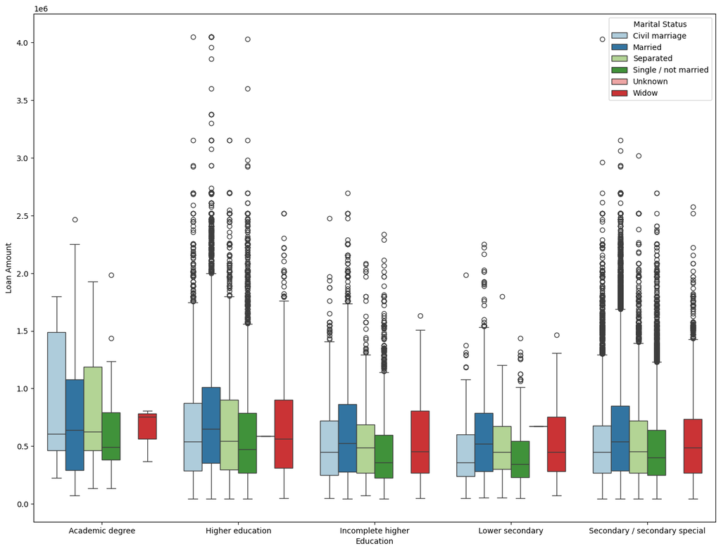

```python
plt.figure(figsize=[16,12])
sns.boxplot(data=df_appl , x='Education',y='Loan Amount',hue = 'Marital Status',orient='v',palette='Paired')
```

#### - Based on the box plot, it can be observed that individuals with a family status of 'civil marriage', 'marriage', and 'separated', who also hold an Academic degree, tend to have a higher number of credits compared to others. Additionally, those with higher education and a family status of 'marriage', 'single', or 'civil marriage' show a greater number of outliers. The 'civil marriage' category for individuals with an Academic degree accounts for the majority of credits in the third quartile.